# Lab 8

Sam Muir

2024-03-06

## Forest Cover Classification with SVM

In this week’s lab we are exploring the use of Support Vector Machines for multi-class classification. Specifically, you will be using cartographic variables to predict forest cover type (7 types).

Natural resource managers responsible for developing ecosystem management strategies require basic descriptive information including inventory data like forest cover type for forested lands to support their decision-making processes. However, managers generally do not have this type of data for in-holdings or neighboring lands that are outside their immediate jurisdiction. One method of obtaining this information is through the use of predictive models.

You task is build both an SVM and a random forest model and compare their performance on accuracy and computation time.

1. The data is available here: https://ucsb.box.com/s/ai5ost029enlguqyyn04bnlfaqmp8kn4

Explore the data.

```r
forest <- read_csv(here::here("week-9", "covtype_sample.csv")) %>%
  janitor::clean_names() %>%
  mutate(cover_type = as.factor(cover_type)) %>%
  mutate(across(6:55, as.factor)) %>%
  select(-soil_type_15) # only have value
#skimr::skim(forest)
```

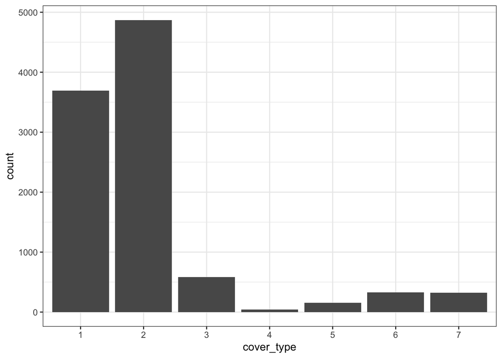

```r
ggplot(forest, aes(x = cover_type)) +
  geom_histogram(stat = "count") +
  theme_bw()
```

- What kinds of features are we working with?

**We have some topographical features that are continuous variables (slope, aspect) and some that are binary (the soil types).**

- Does anything stand out that will affect you modeling choices?

**Some of the continuous variables are not normally distributed. There is also an imbalance in frequency between the cover types.**

Hint: Pay special attention to the distribution of the outcome variable across the classes.

2. Create the recipe and carry out any necessary preprocessing. Can you use the same recipe for both models?
3. Create the folds for cross-validation.
4. Tune the models. Choose appropriate parameters and grids. If the computational costs of tuning given your strategy are prohibitive, how might you work around this?
5. Conduct final predictions for both models and compare their prediction performances and computation costs from part 4.

### Create the recipe and Carry out any necessary preprocessing.

```r
# Split the data into training and testing
split <- initial_split(forest, 0.7, strata = cover_type)
forest_training <- training(split)
forest_testing <- testing(split)

# create recipe
svm_rec <- recipe(cover_type~., data = forest_training) %>%
  step_zv(all_predictors()) %>%
  step_center(all_numeric_predictors()) %>%
  step_scale(all_numeric_predictors())
```

## SVM Poly

```r
svm_linear_spec <- svm_poly(degree = 1,
                            cost = tune()) %>% # cost parameter: width of margin around hyper plane
  set_mode("classification") %>%
  set_engine("kernlab")

svm_linear_wf <- workflow() %>%
  add_model(svm_linear_spec %>%
              set_args(cost_tune())) %>%
  add_formula(cover_type~.)
#svm_linear_wf
```

### Create the folds for cross-validation.

```r
set.seed(258)
forest_fold <- vfold_cv(forest_training, strata = cover_type, v = 2)
```

### Tune the models. Choose appropriate parameters and grids.

```r
doParallel::registerDoParallel(cores = 4) # set up parallel processing for computation efficiency

param_grid <- grid_regular(cost(), levels = 2) # grid; for run-time
```

```r
# tune grid
system.time(
tune_res <- tune_grid(
  svm_linear_wf,
  resamples = forest_fold,
  grid = param_grid
))
#    user  system elapsed
# 421.116  14.748 450.675
```

### Conduct final predictions

```r
# autoplot(tune_res) +
#   theme_bw()

## finalize
best_cost <- select_best(tune_res, metric = "accuracy")
best_cost
```

```
## # A tibble: 1 × 2
##    cost .config
##   <dbl> <chr>
## 1    32 Preprocessor1_Model2
```

```r
svm_linear_final <- finalize_workflow(svm_linear_wf, best_cost)
```

```r
svm_linear_fit <- svm_linear_final %>% fit(forest_training)
svm_linear_augment <- augment(svm_linear_fit, new_data = forest_testing)
```

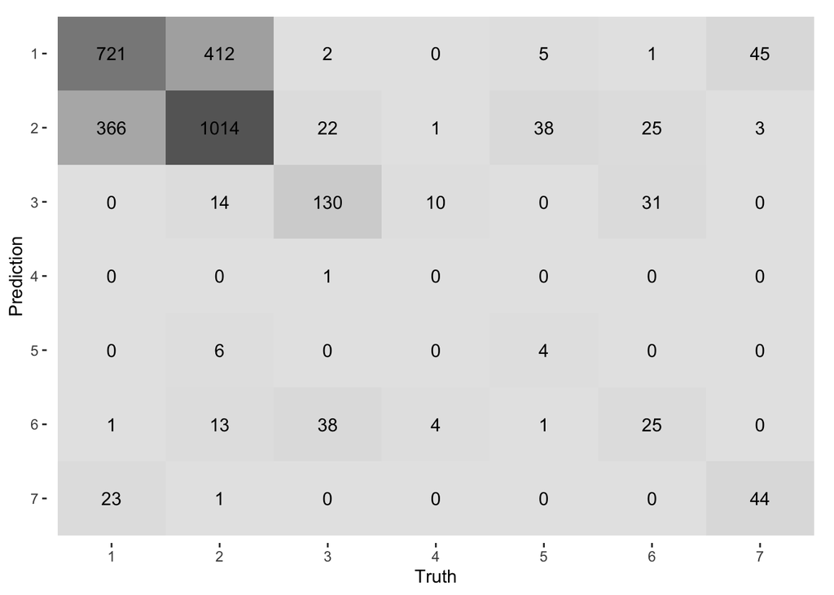

```r
svm_linear_augment %>%
  conf_mat(truth = cover_type, estimate = .pred_class) %>%
  autoplot(type = "heatmap")
```

```r
# svm_linear_augment %>%
#   roc_curve(truth = cover_type, .pred_1, .pred_2, .pred_3, .pred_4, .pred_5, .pred_6, .pred_7) %>%
#   autoplot()

svm_linear_augment %>%
  roc_auc(truth = cover_type, .pred_1, .pred_2, .pred_3, .pred_4, .pred_5, .pred_6, .pred_7)
```

```
## # A tibble: 1 × 3
##   .metric .estimator .estimate
##   <chr>   <chr>          <dbl>
## 1 roc_auc hand_till      0.801
```

## SVM RBF

```r
#svm rbf --------------------
svm_rbf_spec <- svm_rbf() %>%
  set_mode("classification") %>%
  set_engine("kernlab")

svm_rbf_wf <- workflow() %>%
  add_model(svm_rbf_spec %>%
              set_args(cost_tune())) %>%
  add_formula(cover_type~.)
```

```r
system.time(
svm_rbf_fit <- svm_rbf_spec %>%
  fit(cover_type~., data = forest_training))
#    user  system elapsed
# 299.652  14.191 315.562

svm_rbf_augment <- augment(svm_rbf_fit, new_data = forest_testing)
```

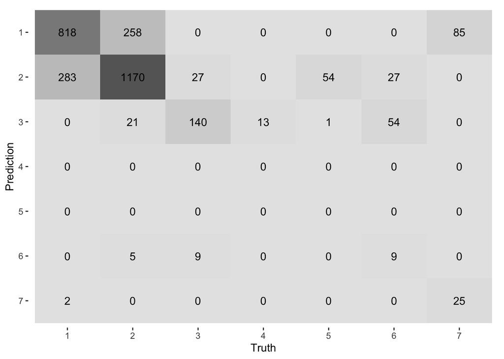

```r
svm_rbf_augment %>%
  conf_mat(truth = cover_type, estimate = .pred_class) %>%
  autoplot(type = "heatmap")
```

```r
#We can examine our model's performance using ROC and AUC
# svm_rbf_augment %>%
#   roc_curve(., truth = cover_type, .pred_1, .pred_2, .pred_3, .pred_4, .pred_5, .pred_6, .pred_7) %>%
#   autoplot()

svm_rbf_augment %>%
  roc_auc(truth = cover_type, .pred_1, .pred_2, .pred_3, .pred_4, .pred_5, .pred_6, .pred_7)
```

```
## # A tibble: 1 × 3
##   .metric .estimator .estimate
##   <chr>   <chr>          <dbl>
## 1 roc_auc hand_till      0.804
```

## Random Forest

### Create the recipe and carry out any necessary preprocessing.

```r
rf_model <- rand_forest(mtry = tune(),
                  trees = tune()) %>%
  set_engine("ranger") %>%
  set_mode("classification")

# workflow ----
rf_workflow <- workflow() %>%
  add_model(rf_model) %>%
  add_recipe(svm_rec) # same recipe as svm
```

### Tune the models. Choose appropriate parameters and grids.

```r
# parameter tuning ----
system.time(
  rf_cv_tune <- rf_workflow %>%
  tune_grid(resamples = forest_fold, grid = 2)) #use cross validation to tune mtry and trees parameters
```

```
##    user  system elapsed
##  39.620   0.613  17.617
```

### Conduct final predictions

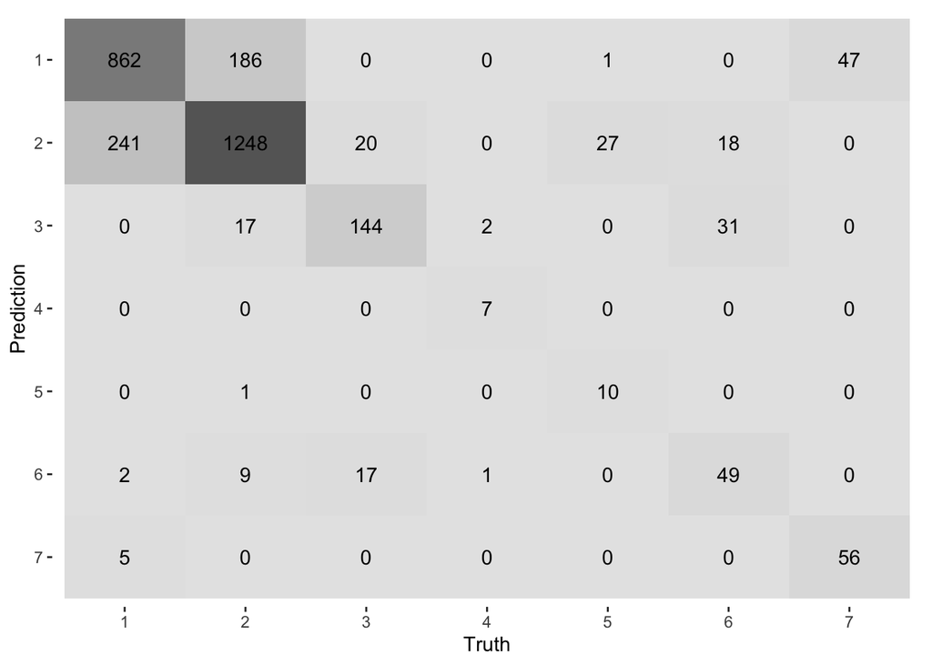

```r
#get metrics from tuning cv to pick best model ----
#collect_metrics(rf_cv_tune)

#plot cv results for parameter tuning ----
# autoplot(rf_cv_tune) +
#   theme_bw()

# finalize workflow ----
rf_best <- show_best(rf_cv_tune, n = 1, metric = "roc_auc") #get metrics for best random forest model
#rf_best

rf_final <- finalize_workflow(rf_workflow,
                              select_best(rf_cv_tune, metric = "roc_auc"))

# model fitting ----
train_fit_rf <- fit(rf_final, forest_training) #fit the model to the training set
#train_fit_rf

# prediction probabilities ----
test_predict_rf <- predict(train_fit_rf, forest_testing) %>% #get testing prediction
  bind_cols(forest_testing) %>%  #bind to testing column
  mutate(cover_type = as.numeric(cover_type),
         cover_type = as.factor(cover_type))

# roc auc curve
# roc_curve(test_predict_rf, cover_type, .pred_class) %>%
#   autoplot()

test_predict_rf %>%
  conf_mat(truth = cover_type, estimate = .pred_class) %>%
  autoplot(type = 'heatmap')
```

```r
test_predict_rf %>%
  accuracy(cover_type, estimate = .pred_class)
```

```
## # A tibble: 1 × 3
##   .metric  .estimator .estimate
##   <chr>    <chr>          <dbl>
## 1 accuracy multiclass     0.792
```

- Which type of model do you think is better for this task?

- Why do you speculate this is the case?

**I think that the random forest was more computationally efficient since it is better for multi-class classification where SVM is better for two-class. There is also a clear imbalance in cover type, as shown by the histograms, and random forest can work through those imbalances better than SVM.**